# markdowntest

Kelly Okech

Monday, June 08, 2015

This is a report detailing the steps I took in answering assignment 1 in reproducible research class.

So, to begin, we’ll load the csv file and probably try to explore the data in it

```r
activity <- read.table("activity.csv", header=T, sep=",")

# convert date to date data type
activity$date <- as.Date(activity$date)
str(activity)
```

```
## 'data.frame':    17568 obs. of  3 variables:
##  $ steps   : int  NA NA NA NA NA NA NA NA NA NA ...
##  $ date    : Date, format: "2012-10-01" "2012-10-01" ...
##  $ interval: int  0 5 10 15 20 25 30 35 40 45 ...
```

Doing away with missing values

```r
# Doing away with na values
activity1 <- na.omit(activity)

#Checking new structure
str(activity1)
```

```
## 'data.frame':    15264 obs. of  3 variables:
##  $ steps   : int  0 0 0 0 0 0 0 0 0 0 ...
##  $ date    : Date, format: "2012-10-02" "2012-10-02" ...
##  $ interval: int  0 5 10 15 20 25 30 35 40 45 ...
##  - attr(*, "na.action")=Class 'omit'  Named int [1:2304] 1 2 3 4 5 6 7 8 9 10 ...
##   .. ..- attr(*, "names")= chr [1:2304] "1" "2" "3" "4" ...
```

Question 1: total mean number of steps taken per day

Grouping the rows into 24hour intervals and determining their sum

```r
daily.steps <- rowsum(activity1$steps, format(activity1$date, '%Y-%m-%d'))
daily.steps <- data.frame(daily.steps)
names(daily.steps) <- ("steps")
```

Plot a histogram of steps variable to explore the data further

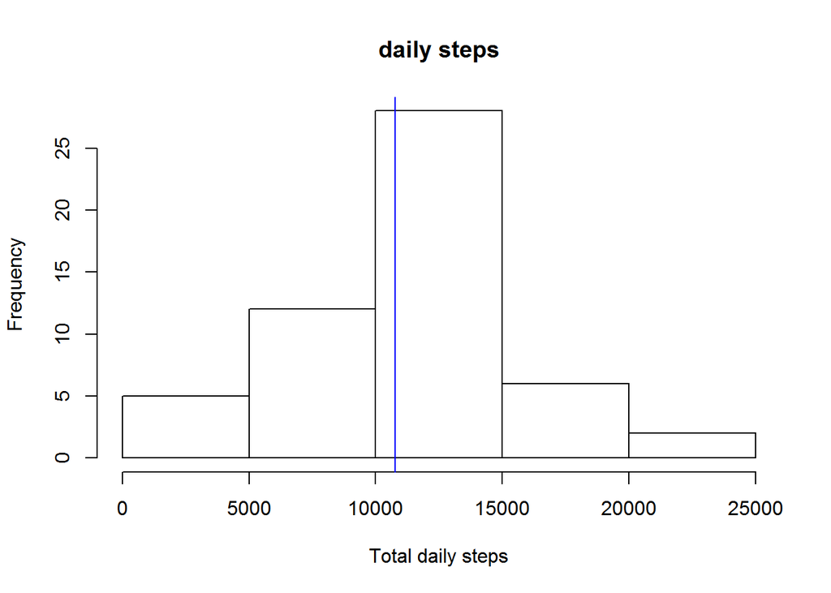

```r
hist(daily.steps$steps, main = "daily steps", xlab = "Total daily steps")
abline(v = mean(daily.steps$steps), col = "Blue")
```

Calculate the mean value

```r
mean(daily.steps$steps)
```

```
## [1] 10766.19
```

Calculate the median value

```r
median(daily.steps$steps)
```

```
## [1] 10765
```

Question 2: Find the average daily activity pattern

```r
library(plyr)
# average steps for each of 5-minute interval during a 24-hour period
interval <- ddply(activity1,~interval, summarise, mean=mean(steps))
```

Time series plot of the intervals and average steps

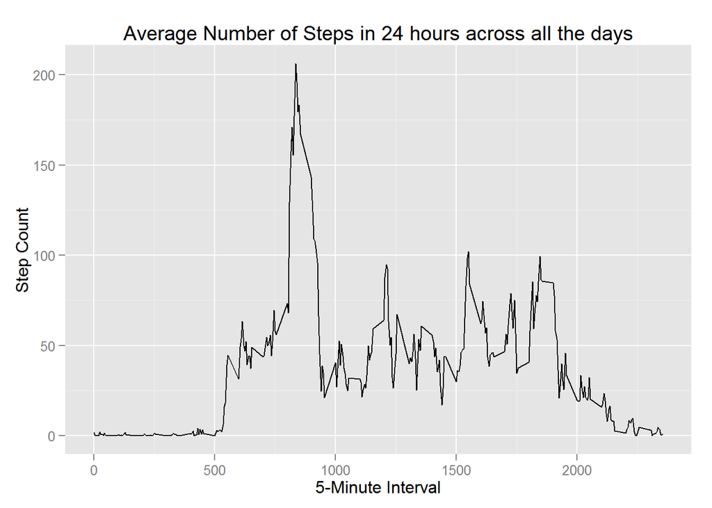

```r
library(ggplot2)
qplot(x=interval, y=mean, data = interval,  geom = "line",
      xlab="5-Minute Interval",
      ylab="Step Count",
      main="Average Number of Steps in 24 hours across all the days"
      )
```

Finding out which 5 minute intervals has the highest number of steps

```r
interval[which.max(interval$mean), ]
```

```
##     interval     mean
## 104      835 206.1698
```

Question 3: imputing missing values

Finding th total number fo missing values in the data set.

```r
#use the str function on data set activity1.Total number of na values is indicated somewhere in there as 2304
str(activity1)
```

```
## 'data.frame':    15264 obs. of  3 variables:
##  $ steps   : int  0 0 0 0 0 0 0 0 0 0 ...
##  $ date    : Date, format: "2012-10-02" "2012-10-02" ...
##  $ interval: int  0 5 10 15 20 25 30 35 40 45 ...
##  - attr(*, "na.action")=Class 'omit'  Named int [1:2304] 1 2 3 4 5 6 7 8 9 10 ...
##   .. ..- attr(*, "names")= chr [1:2304] "1" "2" "3" "4" ...
```

alternatively, you can run this code to find out how many missing values are in the variable ‘steps’

```r
sum(is.na(activity$steps))
```

```
## [1] 2304
```

```r
fill <- activity


#check for missing value
sum(is.na(fill))
```

```
## [1] 2304
```

```r
newsteps<-tapply(fill$steps, fill$date, sum)
```